# preprocessing

2024-09-20

# Set up

## Load libraries

```r
library(dplyr)
```

```r
library(ggplot2)
library(tidyverse)
library(sf)
```

## Set user

```r
#user <- "Claire"
user <- "Sarah"
```

## Set Expendition

Subset dataset based on missing values in a given column Run a conditional “if” statement based on the number of rows that either Returns a message stating no values are missing or Creates a table with the rows that are missing

# Subset dataset and immediately filter out test data (AphiaID = -999)

```r
if(user == "Claire"){
  setwd("~/NOAA/NOAA.Explore.QAQC/R")
  expedition = "EX2306_Survey_Data_20240528.csv"
  survey_df = read.csv(paste0("../../data/",expedition))}

if(user == "Sarah"){
  expedition = "EX2306"
  survey_df = read.csv(paste0("C:/Users/sarah.groves/Documents/Data/EX2306/SME_clean/",expedition, "_Survey_Data_20240528.csv")) |>
    dplyr::filter(AphiaID != -999)}


# Helpful notes:
# paste0: doesn't add separators btw items else paste defaults to single space
# paste: can add optional delimiters (sep = "_")
```

## View columns names

```r
# Column Options
colnames(survey_df)
```

```
##  [1] "SampleID"                         "TrackingID"
##  [3] "Citation"                         "Repository"
##  [5] "ScientificName"                   "VernacularNameCategory"
##  [7] "VernacularName"                   "TaxonRank"
##  [9] "AphiaID"                          "LifeScienceIdentifier"
## [11] "Phylum"                           "Class"
## [13] "Subclass"                         "Order"
## [15] "Suborder"                         "Family"
## [17] "Subfamily"                        "Genus"
## [19] "Subgenus"                         "Species"
## [21] "Subspecies"                       "ScientificNameAuthorship"
## [23] "Morphospecies"                    "CombinedNameID"
## [25] "Synonyms"                         "IdentificationComments"
## [27] "IdentifiedBy"                     "IdentificationDate"
## [29] "IdentificationQualifier"          "IdentificationVerificationStatus"
```

[output cut: 30 more lines]

**Table 1.** Rows missing spatial information: Latitude

```
## [1] "No missing data"
```

**Table 2.** Rows missing spatial information: Longitude

```
## [1] "No missing data"
```

**Table 3.** Rows missing spatial information: Depth (m)

```
## [1] "No missing data"
```

**Fig. 1.** Histogram of annotation Latitude.

```
## [1] "Summary statistics of latitude:"
```

```
##    Min. 1st Qu.  Median    Mean 3rd Qu.    Max.
##   54.13   55.03   55.97   56.38   56.49   60.76
```

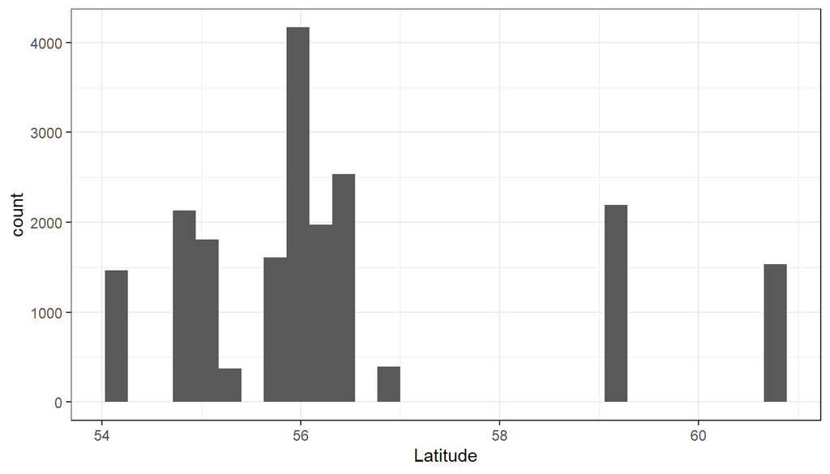

**Fig. 2.** Histogram of annotation Longitude.

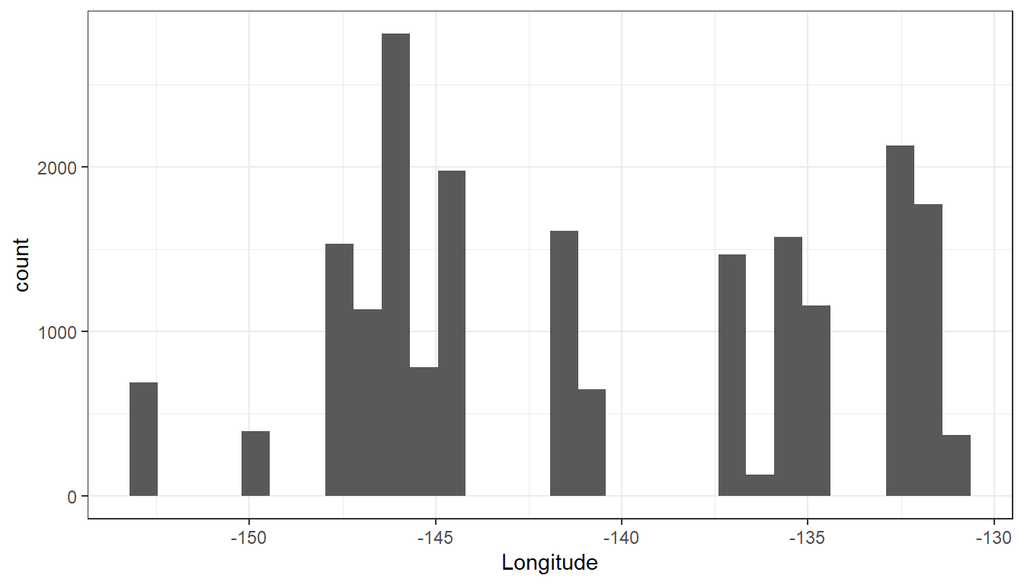

```
## [1] "Summary statistics of longitude:"
```

```
##    Min. 1st Qu.  Median    Mean 3rd Qu.    Max.
##  -152.9  -146.3  -141.7  -140.7  -134.5  -131.1
```

**Fig. 3.** Histogram and probability distribution of Depth.

```
## [1] "Summary statistics of depth (m)"
```

```
##    Min. 1st Qu.  Median    Mean 3rd Qu.    Max.
##   263.6   489.5   791.4  1171.3  1620.2  4260.5
```

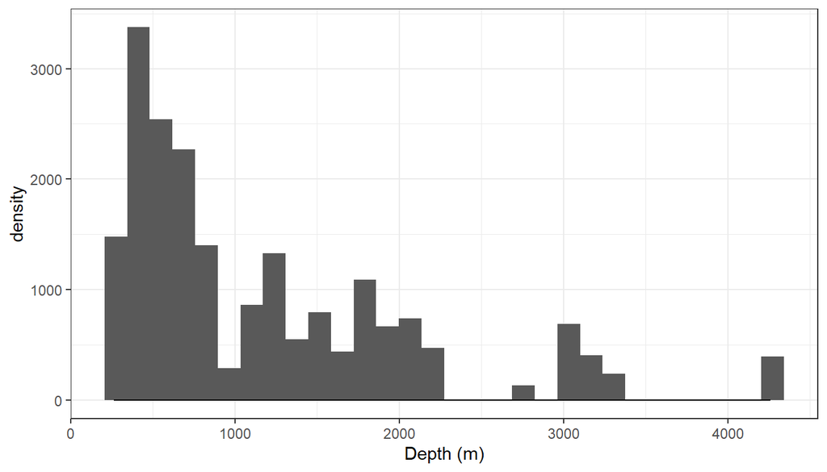

```r
### Data Cleaning ###
# filter function for missing / unexpected values


# filter_df <- function(df, col = NA, filter_type = "missing", return_type = "original", num_missing = 0, unexpected_value = -999, lat_long = NA) {
#   # filter_type:
#   #   -  "missing" : filter na values
#   #   - "unexpected" : filter value stored in unexpected_value
#   # return_type:
#   #   -  original: return the original df filtered for specified values
#   #   -  filtered: return the rows that contain specified / missing value
#   # num_missing:
#   #   - threshold for missing values, return subset if >  num_missing
#   # unexpected_value
#   #   - value to filter unexpected by
#
#   if (filter_type == "missing"){
#     subset_rows = is.na(df[[col]])
#     if (length(subset_rows) > num_missing) {
#       print(paste(length(subset_rows), "missing values in", col))
#     } else {
#       print(paste(nrow(filtered), "missing values in", col))
#     }
#   } else if (filter_type == "unexpected") {
#     subset_rows = df[[col]] == unexpected_value
#     num_unexp = length(subset_rows)
#     print(paste(num_unexp, "unexpected values in", col))
#   } else if (is.na(col) & !is.na(lat_long)){
#     # subset_rows = df %>%
#     #   filter(between(Latitude, lat_long[[1]][1], lat_long[[1]][2]) &
#     #          between(Longitude, lat_long[[2]][1], lat_long[[2]][2]))
#     subset_rows <- df %>%
#       mutate(in_range = between(Latitude, lat_long[[1]][1], lat_long[[1]][2]) &
#                between(Longitude, lat_long[[2]][1], lat_long[[2]][2])) %>%
#       pull(in_range)
#     num_unexp = length(subset_rows)
#     print(paste(num_unexp, "values in not in lat/long range"))
#   }
#
#   filtered <- df[subset_rows, ]
#   df <- df[!subset_rows,]
#   if (return_type == "original"){
#     return(df)
#   } else if (return_type == "filtered"){
#     return(filtered)
#   }
# }
#
# # Check missing
# column <- "TaxonRank"
# head(filter_df(survey_df, column))
#
# # Check unexpected
# column <- "AphiaID"
#head(filter_df(survey_df, column, filter_type = "unexpected", return_type = "original"))

# Check latitude longitude
### Only arctic ocean for now:
#     - latitude: [50, 70]
#     - longitude: [-140, -170]
#latlong = list(c(50, 70), c(-170, -140))

# plot observations on map
#
#head(filter_df(survey_df, column, return_type = "original", lat_long = latlong))
```

```r
#latlong = list(c(50, 70), c(-170, -140))
#head(filter_df(survey_df, column, return_type = "original", lat_long = latlong))
```

# Additional Data Cleaning:

values that dont make sense (ie -999 in AphiaID –> Test data) Time / Location (last yr, all USA) (missing lat / long) only need to check col listed in sheet everything that has -999 need to go into annottaion platform (sea2) –> will get data template

- maybe learn SQL if time permits

# Plotting

- distributions
- geographical loc. map
- hist. / ggmap / plotly
- https://r.geocompx.org/adv-map
- try and find some map background
- shape files
- plot all the diff annotations for the ROV
- by time and by geo.

## Distribution

````r
# # conditions:
# ### "Temperature", "Salinity", "Oxygen",
# # species
# ### Phylum, Class, Subclass, Order, Suborder, Family, Subfamily, Genus, Subgenus, Species, Subspecies
# # time
# ### IdentificationDate, ObservationDate, ObservationTime
# # spatial
# ### DepthInMeters, MinimumDepthInMeters, MaximumDepthInMeters
#
#
# filter_df(survey_df, col = "Temperature") %>%
#   ggplot(aes(x=Temperature)) +
#   geom_histogram()
#
# survey_df = filter_df(survey_df, col = "Temperature")
# survey_df = filter_df(survey_df, col = "DepthInMeters")
# survey_df = filter_df(survey_df, col = "Phylum")
#
# survey_df %>%
#   ggplot(aes(x=Temperature, y=DepthInMeters, color=Phylum)) +
#   geom_point()
#
# ```
#
# ## Geographic Location
#
# ```{r}
# ### Plot geographic location using ggplot ###
# # option to color by species / depth / other condition
# # conditions:
# ### "Temperature", "Salinity", "Oxygen",
# # species
# ### Phylum, Class, Subclass, Order, Suborder, Family, Subfamily, Genus, Subgenus, Species, Subspecies
# # time
# ### IdentificationDate, ObservationDate, ObservationTime
# # spatial
# ### DepthInMeters, MinimumDepthInMeters, MaximumDepthInMeters
#
#
# set.seed(3)
# survey_df = filter_df(survey_df, col="Oxygen")
# survey_sf <- survey_df %>%
#   st_as_sf(coords = c('Longitude', 'Latitude')) %>%
#   st_set_crs(4326) # using 4326 for lat/lon decimal
#
#
# ggplot() +
#   geom_sf(data = survey_sf, aes(color = Oxygens), size = 3)
````

```r
### Plots geographic location + background map ###
# Makes my computer lag

# library(sp)
# library(leaflet)
#
# coordinates(survey_df) <- ~Longitude + Latitude
#
# # Plot the data using leaflet
# leaflet(survey_df) %>%
#   addTiles() %>%
#   addMarkers()
```